# Project 6 - Risk-Taking Decisions

Ye Dam Yi

3/30/2021

# Risk-Taking Decisions and Emotions

```r
#install.packages("labelled")
library(tidyverse)
library(labelled)
library(ggpubr)
library(rstatix)
# import data
risk <- read_csv("/Users/yedam/Documents/Academic/WFU/Psychology/Projects/First Year Project/Main/Data/Data Files/clean data_excluded.csv", na = c("", "NA"))
glimpse(risk)
```

```
## Rows: 1,418
## Columns: 39
## $ id                     <dbl> 3, 14, 17, 34, 42, 54, 60, 62, 66, 69, 103, 105…
## $ StartDate              <chr> "3/22/2020 20:18:31", "3/22/2020 21:42:14", "3/…
## $ EndDate                <chr> "3/22/2020 20:27:53", "3/22/2020 22:06:14", "3/…
## $ completiontime         <dbl> 561, 1440, 1719, 1783, 690, 621, 471, 748, 1070…
## $ pagesubmitp            <dbl> 101.810, 177.874, 591.739, 197.570, 74.381, 59.…
## $ pagesubmit1            <dbl> 83.658, 356.129, 147.911, 393.643, 154.848, 161…
## $ pagesubmit2            <dbl> 76.535, 224.600, 117.532, 314.783, 110.912, 77.…
## $ pagesubmit3            <dbl> 94.852, 222.925, 152.320, 452.108, 84.575, 85.7…
## $ pagesubmit4            <dbl> 59.255, 282.302, 131.928, 275.491, 102.875, 75.…
## $ submissiontime         <dbl> 416.110, 1263.830, 1141.430, 1633.595, 527.591,…
## $ Finished               <dbl> 1, 1, 1, 1, 1, 1, 1, 1, 1, 1, 1, 1, 1, 1, 1, 1,…
## $ agenum                 <dbl> 57, 23, 27, 25, 31, 38, 35, 38, 36, 38, 49, 33,…
## $ Gender                 <dbl> 1, 1, 1, 1, 1, 1, 1, 1, 1, 1, 1, 1, 1, 1, 1, 1,…
```

[output cut: 26 more lines]

```r
# drop some variables and convert column names into lowercase
risk <- risk %>%
  select(-c("StartDate", "EndDate", "Finished", pagesubmitp:pagesubmit4, Gloomy:NYC)) %>%
  rename_with(tolower) %>%
  mutate(gender = as.factor(gender))
glimpse(risk)
```

```
## Rows: 1,418
## Columns: 28
## $ id                     <dbl> 3, 14, 17, 34, 42, 54, 60, 62, 66, 69, 103, 105…
## $ completiontime         <dbl> 561, 1440, 1719, 1783, 690, 621, 471, 748, 1070…
## $ submissiontime         <dbl> 416.110, 1263.830, 1141.430, 1633.595, 527.591,…
## $ agenum                 <dbl> 57, 23, 27, 25, 31, 38, 35, 38, 36, 38, 49, 33,…
## $ gender                 <fct> 1, 1, 1, 1, 1, 1, 1, 1, 1, 1, 1, 1, 1, 1, 1, 1,…
## $ gencond                <dbl> 5, 5, 5, 5, 5, 5, 5, 5, 5, 5, 5, 5, 5, 5, 5, 5,…
## $ condition              <dbl> 1, 1, 1, 1, 1, 1, 1, 1, 1, 1, 1, 1, 1, 1, 1, 1,…
## $ decision1              <dbl> 0, 0, 1, 1, 1, 0, 1, 1, 1, 0, 1, 1, 1, 1, 1, 0,…
## $ decision2              <dbl> 0, 1, 1, 1, 0, 0, 1, 1, 1, 0, 1, 1, 1, 1, 1, 1,…
## $ decision3              <dbl> 0, 0, 1, 1, 1, 0, 1, 0, 1, 0, 0, 1, 1, 1, 1, 1,…
## $ decision4              <dbl> 1, 1, 1, 1, 1, 0, 1, 0, 1, 0, 0, 1, 1, 1, 0, 1,…
## $ risktaking             <dbl> 1, 2, 4, 4, 3, 0, 4, 2, 4, 0, 2, 4, 4, 4, 3, 3,…
## $ posout                 <dbl> 1, 4, 5, 5, 5, 5, 3, 3, 3, 1, 3, 4, 4, 5, 5, 5,…
## $ posfeel                <dbl> 0, 4, 6, 4, 5, 5, 4, 4, 3, 2, 4, 4, 4, 1, 6, 5,…
## $ negout                 <dbl> 5, 5, 2, 2, 4, 1, 1, 5, 5, 6, 3, 0, 1, 5, 2, 2,…
## $ negfeel                <dbl> 5, 4, 1, 1, 3, 1, 1, 5, 5, 5, 3, 0, 1, 1, 1, 2,…
## $ recipient              <dbl> 0, 0, 0, 0, 0, 0, 0, 0, 0, 0, 0, 0, 0, 0, 0, 0,…
## $ experiencedemotions    <dbl> 0, 0, 0, 0, 0, 0, 0, 0, 0, 0, 0, 0, 0, 0, 0, 0,…
## $ interaction            <dbl> 0, 0, 0, 0, 0, 0, 0, 0, 0, 0, 0, 0, 0, 0, 0, 0,…
## $ attentioncheck         <dbl> 1, 1, 1, 1, 1, 1, 1, 1, 1, 1, 1, 1, 1, 1, 1, 1,…
## $ validity               <dbl> 1, 1, 1, 1, 1, 1, 1, 1, 1, 1, 1, 1, 1, 1, 1, 1,…
## $ excluded               <dbl> 0, 0, 0, 0, 0, 0, 0, 0, 0, 0, 0, 0, 0, 0, 0, 0,…
## $ submissiontimestat     <dbl> 1, 1, 1, 1, 1, 1, 1, 1, 1, 1, 1, 1, 1, 1, 1, 1,…
## $ code                   <chr> "Gary30025", "AsdfBB123", "EJIDF589", "fgh56lop…
## $ zre_1                  <dbl> -0.69464666, 0.02702144, 1.23382867, 1.23382867…
## $ zre_2                  <dbl> -0.69464666, 0.02702144, 1.23382867, 1.23382867…
## $ recipient_mc           <dbl> 0, 0, 0, 0, 0, 0, 0, 0, 0, 0, 0, 0, 0, 0, 0, 0,…
## $ experiencedemotions_mc <dbl> 0, 0, 0, 0, 0, 0, 0, 0, 0, 0, 0, 0, 0, 0, 0, 0,…
```

```r
# check factor levels - gender, recipient, experiencedemotions, condition
nlevels(risk$gender)
```

```
## [1] 2
```

```r
nlevels(risk$recipient)
```

```
## [1] 0
```

```r
nlevels(risk$experiencedemotions)
```

```
## [1] 0
```

```r
nlevels(risk$condition)
```

```
## [1] 0
```

```r
# convert into categorical variables
risk2 <- risk %>%
  mutate(recipient <- labelled(recipient, c(Self = 0, Other = 1)),
         gender <- labelled(gender, c(Male = 1, Female = 2)),
         condition <- labelled(condition, c("Other Control" = 0, "Self Control" = 1, "Other Emotion" = 2, "Self Emotion" = 3)),
    recipient = as.factor(recipient),
         experiencedemotions = as.factor(experiencedemotions),
         condition = as.factor(condition))

# write data
write_csv(risk, file = "data/risk.csv")
```

### Q1: Do people more risk-taking decisions for others than for themselves?

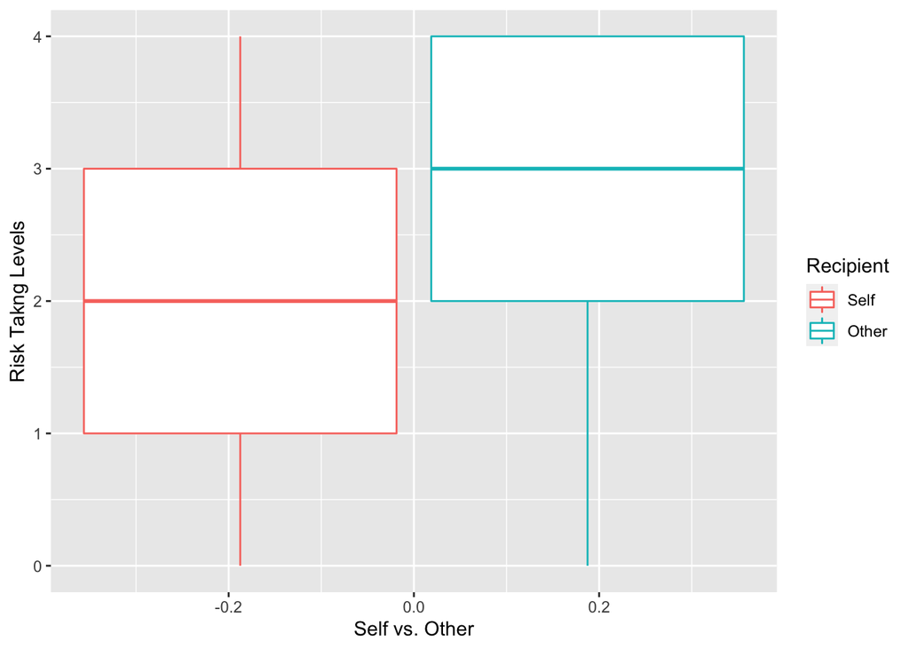

```r
# plot data
risk2 %>%
  ggplot(aes(y = risktaking, color = recipient)) +
  geom_boxplot() +
  labs(
    color = "Recipient",
    y = "Risk Takng Levels",
    x = "Self vs. Other"
  ) +
  scale_color_hue(labels = c("Self", "Other"))
```

```r
# look at descriptive info
risk2 %>%
  select("risktaking", "recipient") %>%
  group_by(recipient) %>%
  summarize(mean = mean(risktaking),
            sd = sd(risktaking),
            min = min(risktaking),
            max = max(risktaking),
            median = median(risktaking))
```

```
## # A tibble: 2 x 6
##   recipient  mean    sd   min   max median
## * <fct>     <dbl> <dbl> <dbl> <dbl>  <dbl>
## 1 0          2.14  1.19     0     4      2
## 2 1          2.83  1.06     0     4      3
```

```r
# check normality assumption
risk2 %>%
  group_by(recipient) %>%
  shapiro_test(risktaking)
```

```
## # A tibble: 2 x 4
##   recipient variable   statistic        p
##   <fct>     <chr>          <dbl>    <dbl>
## 1 0         risktaking     0.914 5.31e-20
## 2 1         risktaking     0.856 1.50e-24
```

```r
# test this trend - model
m_self_other <- lm(risktaking ~ recipient, risk)
summary(m_self_other)
```

```
##
## Call:
## lm(formula = risktaking ~ recipient, data = risk)
##
## Residuals:
##     Min      1Q  Median      3Q     Max
## -2.8277 -0.8277  0.1723  0.8595  1.8595
##
## Coefficients:
##             Estimate Std. Error t value Pr(>|t|)
## (Intercept)  2.14052    0.04158   51.48   <2e-16 ***
## recipient    0.68722    0.05982   11.49   <2e-16 ***
## ---
## Signif. codes:  0 '***' 0.001 '**' 0.01 '*' 0.05 '.' 0.1 ' ' 1
##
## Residual standard error: 1.126 on 1416 degrees of freedom
## Multiple R-squared:  0.08526,    Adjusted R-squared:  0.08461
## F-statistic:   132 on 1 and 1416 DF,  p-value: < 2.2e-16
```

```r
# test this trend - t test
t_self_other <- risk2 %>%
  t_test(risktaking ~ recipient)
t_self_other
```

```
## # A tibble: 1 x 8
##   .y.        group1 group2    n1    n2 statistic    df        p
## * <chr>      <chr>  <chr>  <int> <int>     <dbl> <dbl>    <dbl>
## 1 risktaking 0      1        733   685     -11.5 1412. 1.77e-29
```

The plot and the inferential test show that people take more risk for others (M = 2.83) than for themselves (M = 2.14), p <.001.

### Q2: Does that trend differ for females vs. males?

```r
# check gender levels
levels(risk2$gender)
```

```
## [1] "1" "2"
```

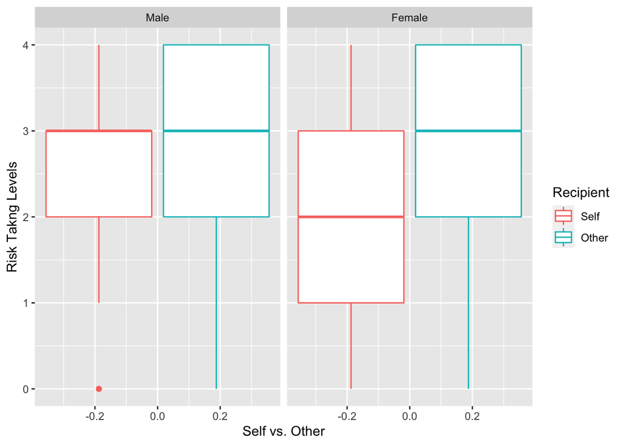

```r
# create gender labels
gender_labels <- c(
  '1' = "Male",
  '2' = "Female"
)

# plot data
risk2 %>%
  ggplot(aes(y = risktaking, color = recipient)) +
  geom_boxplot() +
  facet_wrap(~gender, labeller = as_labeller(gender_labels)) +
  labs(
    color = "Recipient",
    y = "Risk Takng Levels",
    x = "Self vs. Other"
  ) +
  scale_color_hue(labels = c("Self", "Other"))
```

```r
# look at descriptive info
risk2 %>%
  select(risktaking, recipient, gender) %>%
  group_by(recipient, gender) %>%
  summarize(mean = mean(risktaking),
            sd = sd(risktaking),
            min = min(risktaking),
            max = max(risktaking),
            median = median(risktaking))
```

```
## # A tibble: 4 x 7
## # Groups:   recipient [2]
##   recipient gender  mean    sd   min   max median
##   <fct>     <fct>  <dbl> <dbl> <dbl> <dbl>  <dbl>
## 1 0         1       2.50  1.19     0     4      3
## 2 0         2       1.9   1.12     0     4      2
## 3 1         1       2.92  1.12     0     4      3
## 4 1         2       2.78  1.01     0     4      3
```

```r
# check normality assumption
risk2 %>%
  shapiro_test(risktaking)
```

```
## # A tibble: 1 x 3
##   variable   statistic        p
##   <chr>          <dbl>    <dbl>
## 1 risktaking     0.895 4.47e-30
```

```r
risk2 %>% group_by(gender) %>%
  shapiro_test(risktaking)
```

```
## # A tibble: 2 x 4
##   gender variable   statistic        p
##   <fct>  <chr>          <dbl>    <dbl>
## 1 1      risktaking     0.865 3.92e-21
## 2 2      risktaking     0.906 7.11e-23
```

```r
# test this trend - t test
t_self_other_gen <- risk2 %>%
  group_by(gender) %>%
  t_test(risktaking ~ recipient)
t_self_other_gen
```

```
## # A tibble: 2 x 9
##   gender .y.        group1 group2    n1    n2 statistic    df        p
## * <fct>  <chr>      <chr>  <chr>  <int> <int>     <dbl> <dbl>    <dbl>
## 1 1      risktaking 0      1        293   244     -4.16  527. 3.66e- 5
## 2 2      risktaking 0      1        440   441    -12.2   869. 1.50e-31
```

The plot seems that males and females have different patterns of risk-taking for self and others but the inferential test showed that their pattern is about the same - both male and females take more risk take for others than for themselves, which is in line with the literature.

### Q3: Do people in the control condition make more risk-taking decisions for others than for themselves to a greater extent than those in the emotion induction condition do?

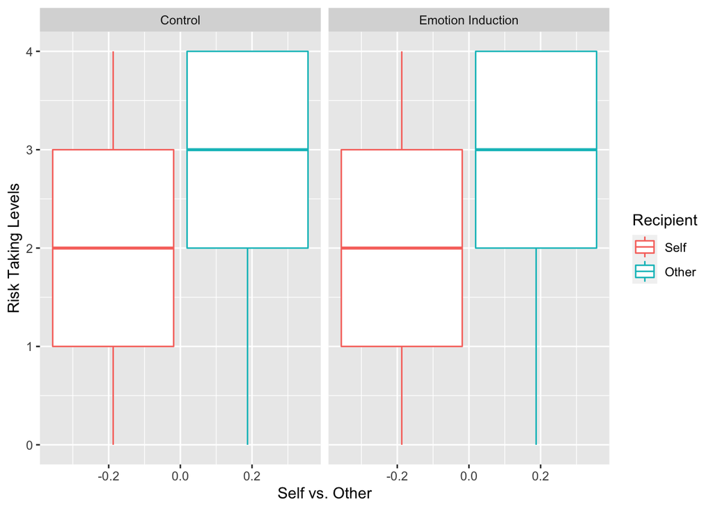

```r
# create a condition label set
condition_labels <- c(
  '0' = "Control",
  '1' = "Emotion Induction"
)

# plot
risk2 %>%
  ggplot(aes(y = risktaking, color = recipient)) +
  geom_boxplot() +
  facet_wrap(~ experiencedemotions, labeller = as_labeller(condition_labels)) +
  labs(
    x = "Self vs. Other",
    y = "Risk Taking Levels",
    color = "Recipient"
  ) +
    scale_color_hue(labels = c("Self", "Other"))
```

```r
# look at descriptives
risk2 %>%
  group_by(recipient, experiencedemotions) %>%
  summarize(mean = mean(risktaking),
            sd = sd(risktaking),
            min = min(risktaking),
            max = max(risktaking),
            median = median(risktaking))
```

```
## # A tibble: 4 x 7
## # Groups:   recipient [2]
##   recipient experiencedemotions  mean    sd   min   max median
##   <fct>     <fct>               <dbl> <dbl> <dbl> <dbl>  <dbl>
## 1 0         0                    2.20  1.14     0     4      2
## 2 0         1                    2.09  1.22     0     4      2
## 3 1         0                    2.87  1.02     0     4      3
## 4 1         1                    2.79  1.08     0     4      3
```

There seems to be no qualitative difference between the control and emotion induction conditions in the extent to which people make different decisions for others than for themselves under risk.

### Q4: Do people making decisions for others feel more or less negative emotions?

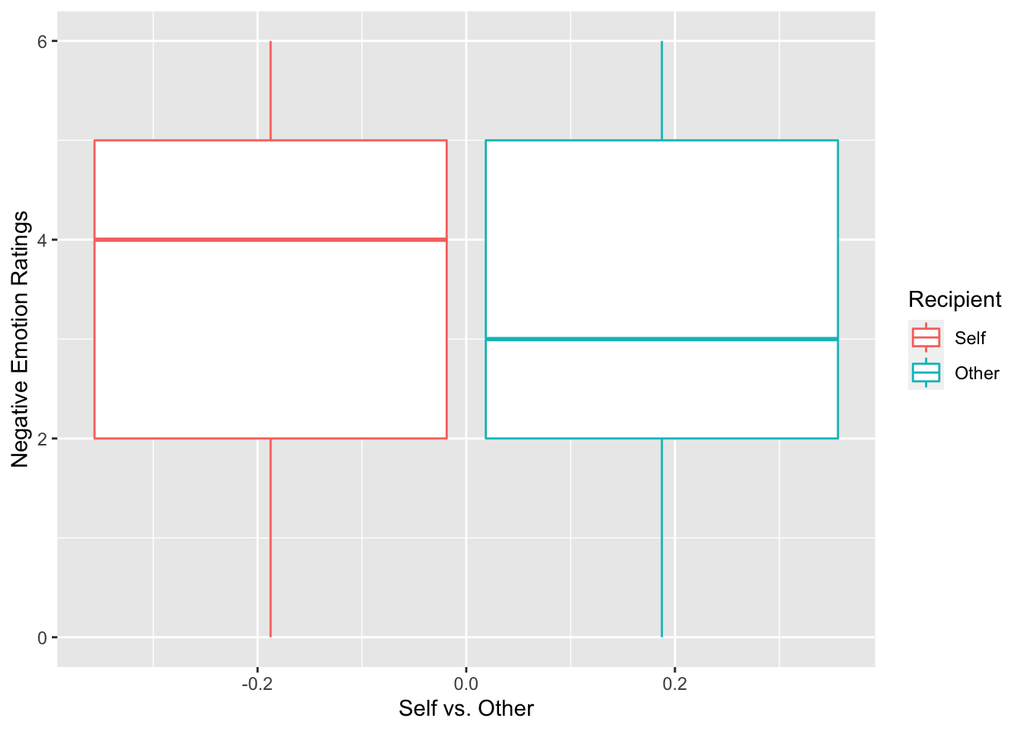

```r
# plot the data
risk2 %>%
  ggplot(aes(y = negfeel, color = recipient)) +
  geom_boxplot() +
  labs(
    x = "Self vs. Other",
    y = "Negative Emotion Ratings",
    color = "Recipient"
  ) +
  scale_color_hue(labels = c("Self", "Other"))
```

```r
# get descriptives
# look at descriptive info
risk2 %>%
  select(negfeel, recipient) %>%
  group_by(recipient) %>%
  summarize(mean = mean(negfeel),
            sd = sd(negfeel),
            min = min(negfeel),
            max = max(negfeel),
            median = median(negfeel))
```

```
## # A tibble: 2 x 6
##   recipient  mean    sd   min   max median
## * <fct>     <dbl> <dbl> <dbl> <dbl>  <dbl>
## 1 0          3.32  1.71     0     6      4
## 2 1          3.13  1.71     0     6      3
```

```r
# test this trend - t test
t_self_other_negfeel <- risk2 %>%
  t_test(negfeel ~ recipient)
t_self_other_negfeel
```

```
## # A tibble: 1 x 8
##   .y.     group1 group2    n1    n2 statistic    df      p
## * <chr>   <chr>  <chr>  <int> <int>     <dbl> <dbl>  <dbl>
## 1 negfeel 0      1        733   685      2.03 1410. 0.0421
```

People feel more negative emotions for themselves than for others when making decisions under risk.

### Q5: Do people making decisions for others feel more or less positive emotions?

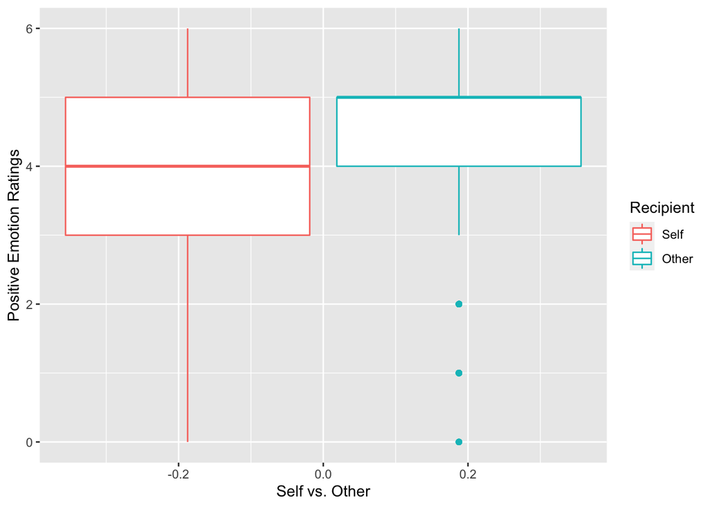

```r
# plot the data
risk2 %>%
  ggplot(aes(y = posfeel, color = recipient)) +
  geom_boxplot() +
  labs(
    x = "Self vs. Other",
    y = "Positive Emotion Ratings",
    color = "Recipient"
  ) +
  scale_color_hue(labels = c("Self", "Other"))
```

```r
# get descriptives
# look at descriptive info
risk2 %>%
  select(posfeel, recipient) %>%
  group_by(recipient) %>%
  summarize(mean = mean(posfeel),
            sd = sd(posfeel),
            min = min(posfeel),
            max = max(posfeel),
            median = median(posfeel))
```

```
## # A tibble: 2 x 6
##   recipient  mean    sd   min   max median
## * <fct>     <dbl> <dbl> <dbl> <dbl>  <dbl>
## 1 0          3.91  1.50     0     6      4
## 2 1          4.32  1.28     0     6      5
```

```r
# test this trend - t test
t_self_other_posfeel <- risk2 %>%
  t_test(posfeel ~ recipient)
t_self_other_posfeel
```

```
## # A tibble: 1 x 8
##   .y.     group1 group2    n1    n2 statistic    df            p
## * <chr>   <chr>  <chr>  <int> <int>     <dbl> <dbl>        <dbl>
## 1 posfeel 0      1        733   685     -5.46 1405. 0.0000000572
```

People feel more positive emotions for others than for themselves when making decisions under risk.

### Q6: Do emotions influence risk-taking levels differently for personal decisions and for surrogate decisions? Is the effect of negative and positive emotions on risk-taking levels moderated by who is being decided for?

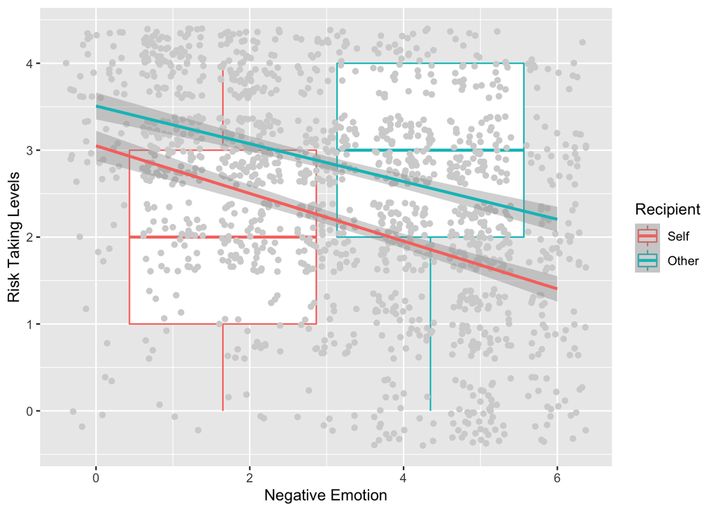

```r
# plot the data - negfeel
risk2 %>%
  ggplot(aes(x = negfeel, color = recipient, y = risktaking)) +
  geom_boxplot() +
  geom_jitter(color = "light grey") +
  geom_smooth(method = "lm") +
  labs(
    x = "Negative Emotion",
    y = "Risk Taking Levels",
    color = "Recipient"
  ) +
  scale_color_hue(labels = c("Self", "Other"))
```

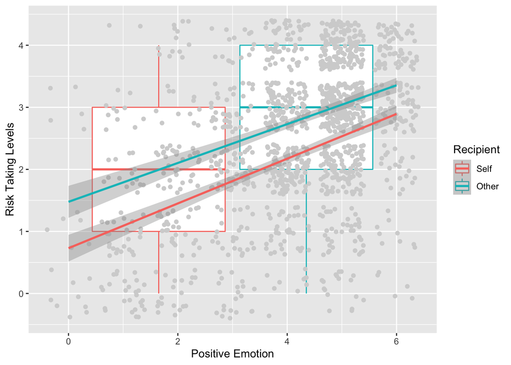

```r
# plot the data - posfeel
risk2 %>%
  ggplot(aes(x = posfeel, color = recipient, y = risktaking)) +
  geom_boxplot(aes(group = recipient)) +
  geom_jitter(color = "light grey") +
  geom_smooth(aes(group = recipient), method = lm) +
  labs(
    x = "Positive Emotion",
    y = "Risk Taking Levels",
    color = "Recipient"
  ) +
  scale_color_hue(labels = c("Self", "Other"))
```

It seems that the relationship between negative and positive emotions and risk-taking levels don’t really differ across personal decisions and surrogate decisions.

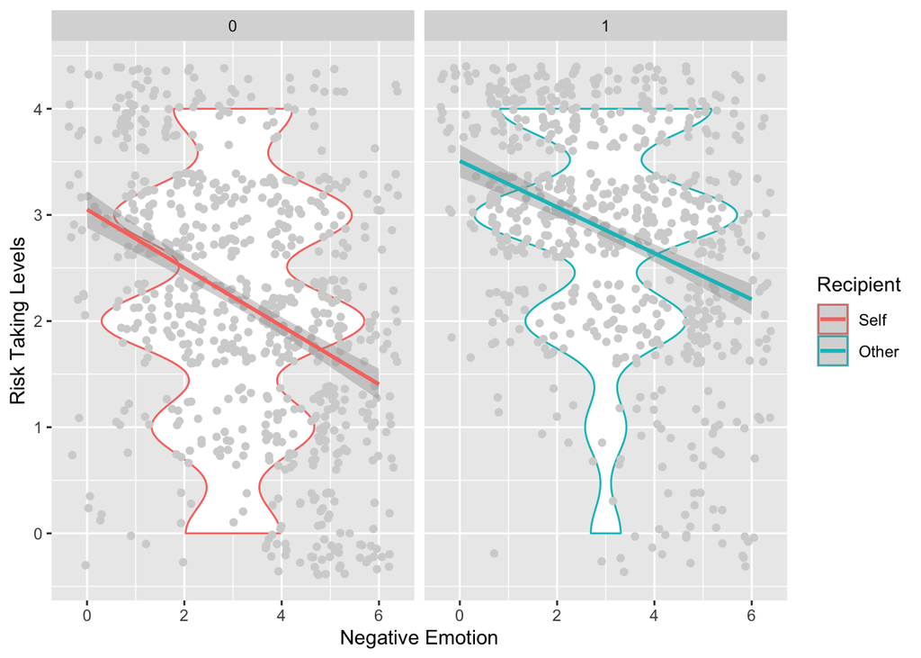

```r
# plot the data - negfeel
risk2 %>%
  ggplot(aes(x = negfeel, color = recipient, y = risktaking)) +
  geom_violin() +
  geom_jitter(color = "light grey") +
  facet_wrap(~recipient) +
  geom_smooth(method = "lm") +
  labs(
    x = "Negative Emotion",
    y = "Risk Taking Levels",
    color = "Recipient"
  ) +
  scale_color_hue(labels = c("Self", "Other"))
```

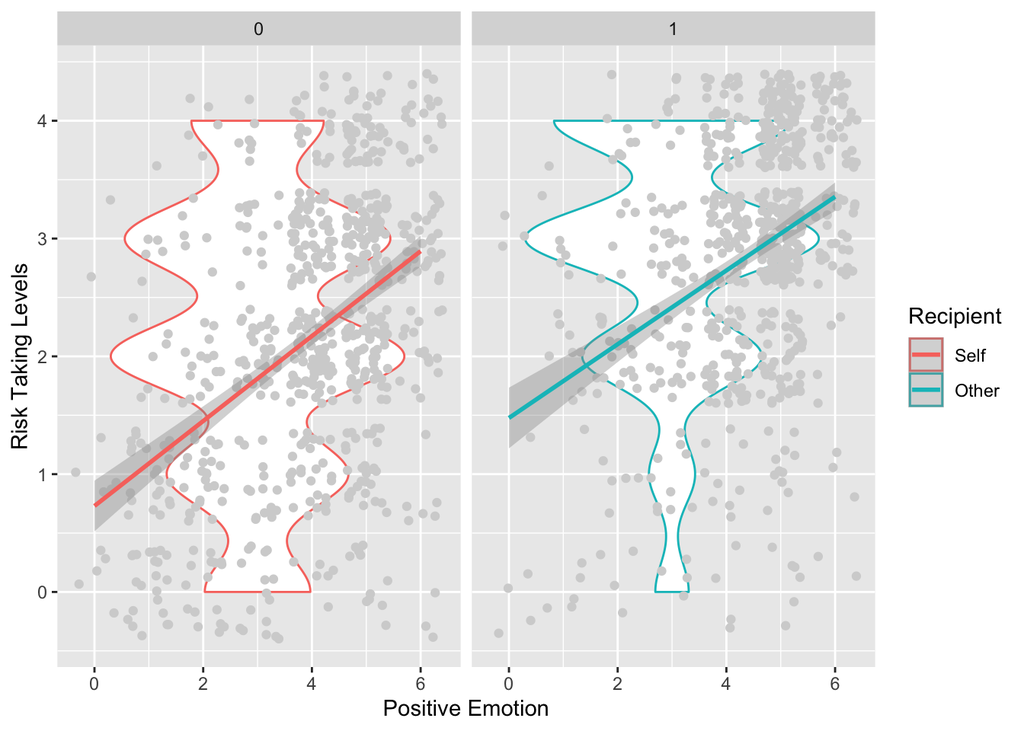

```r
# plot the data - posfeel
risk2 %>%
  ggplot(aes(x = posfeel, color = recipient, y = risktaking)) +
  geom_violin() +
  geom_jitter(color = "light grey") +
  facet_wrap(~recipient) +
  geom_smooth(method = "lm") +
  labs(
    x = "Positive Emotion",
    y = "Risk Taking Levels",
    color = "Recipient"
  ) +
  scale_color_hue(labels = c("Self", "Other"))
```

### Thoughts

I’m not really sure why the data points look like they are in a grid pattern. I’m also not sure how to anchor the regression lines to each of the boxplots that they are relevant to, which is what Mason did in one of her graphs she shared with me and Eric. It looked really nice.

It was helpful to learn that there was a package called “rstatix” that allows piping with inferential statistics.